# Forecasting Liquidated Firm Count

##### Oguzhan Pinar - IE360 HW3 - Fall 2020

```python
import pandas as pd
import numpy as np
import datetime as dt
import matplotlib.pyplot as plt
import seaborn as sns
from sklearn.preprocessing import MinMaxScaler
import statsmodels.api as sm
import math
from sklearn.linear_model import LinearRegression
from statsmodels.api import OLS

#Set the width of notebook
from IPython.core.display import display, HTML
display(HTML("<style>.container { width:70% !important; }</style>"))
```

# 1. Introduction

In an economy, the term liquidation is used to define the process of the end of a firm and distributing its assets to claimants. The number of liquidated firms plays a crucial role to analyze and make decisions about the economy. From governers to financial institutions the statistics is used behind the economic decisions like credit allocation decisions, macroecenomic decisions etc. However, the statistics is announced after the month passed which causes the decisions are made with old data. Therefore, the future values of liquadated firm number is important for some firms, governers etc.

In this study, I will build a linear regression model that forecasts the number of liquidated firms in the next month. Throughout my analysis, I will first handle the issues of the target variable like seosanality, trend, etc. Than, I will try do improve my model by adding some other features like USD/TRY, commercial_credit_int_rate, reel_sector_confidence_index, general_business_situation, general_economic_situation_present, "general_economic_situation_expectation".

# 2. Analysis

## 2.1. Import Data and Build Time Series Object

```python
data = pd.read_excel("EVDS.xlsx", skipfooter=46)
data = data.iloc[42:]
data
```

|  | Tarih | TP DK USD S YTL | TP KTF17 | TP GY1 N2 | TP GY9 N2 | TP TG2 Y04 | TP TG2 Y05 | TP KAP2 TOP A |
| --- | --- | --- | --- | --- | --- | --- | --- | --- |
| 42 | 2012-01 | 1.847814 | 15.2975 | 102.0 | 96.9 | 98.085568 | 102.247197 | 2449.0 |
| 43 | 2012-02 | 1.759533 | 14.8650 | 108.7 | 106.0 | 99.959481 | 103.485620 | 1094.0 |
| 44 | 2012-03 | 1.787882 | 14.1840 | 112.6 | 106.8 | 100.556749 | 102.921379 | 869.0 |
| 45 | 2012-04 | 1.788420 | 14.1825 | 115.4 | 107.7 | 94.290142 | 94.763702 | 882.0 |
| 46 | 2012-05 | 1.805627 | 14.0475 | 114.3 | 105.5 | 99.401858 | 102.165174 | 1123.0 |
| ... | ... | ... | ... | ... | ... | ... | ... | ... |
| 145 | 2020-08 | 7.265250 | 12.8500 | 106.2 | 100.7 | 68.616596 | 79.501970 | 1305.0 |
| 146 | 2020-09 | 7.521323 | 14.2850 | 105.3 | 94.7 | 71.919256 | 83.347919 | 1582.0 |
| 147 | 2020-10 | 7.888071 | 15.2320 | 108.1 | 101.4 | 66.256658 | 81.434985 | 1331.0 |
| 148 | 2020-11 | 8.017762 | 17.1875 | 103.9 | 101.3 | 61.078587 | 78.728868 | 986.0 |
| 149 | 2020-12 | 7.734970 | 18.9700 | 106.8 | 101.5 | 60.890511 | 82.860028 | NaN |

108 rows × 8 columns

```python
### 1. Import data ###
data = pd.read_excel("EVDS.xlsx", skipfooter=46)
data = data.iloc[42:]

### 2. Set column names ###
data.columns = ["date",
                "usd_try",
                "commercial_credit_int_rate",
                "reel_sector_confidence_index",
                "general_business_situation",
                "general_economic_situation_present",
                "general_economic_situation_expectation",
                "liquidated_total"
               ]


### 3. Build time series object (reindex as datetime object)###
data.date = data.date.apply(lambda x: dt.datetime.strptime(x, "%Y-%m"))
data = data.set_index("date")

### 4. Seperate last month's data I will use it to guess the level in December 2020 ###
december_2020 = data.loc[dt.datetime(2020,12,1)]
data = data.loc[data.index<dt.datetime(2020,12,1)]
data
```

| date | usd_try | commercial_credit_int_rate | reel_sector_confidence_index | general_business_situation | general_economic_situation_present | general_economic_situation_expectation | liquidated_total |
| --- | --- | --- | --- | --- | --- | --- | --- |
| 2012-01-01 | 1.847814 | 15.2975 | 102.0 | 96.9 | 98.085568 | 102.247197 | 2449.0 |
| 2012-02-01 | 1.759533 | 14.8650 | 108.7 | 106.0 | 99.959481 | 103.485620 | 1094.0 |
| 2012-03-01 | 1.787882 | 14.1840 | 112.6 | 106.8 | 100.556749 | 102.921379 | 869.0 |
| 2012-04-01 | 1.788420 | 14.1825 | 115.4 | 107.7 | 94.290142 | 94.763702 | 882.0 |
| 2012-05-01 | 1.805627 | 14.0475 | 114.3 | 105.5 | 99.401858 | 102.165174 | 1123.0 |
| ... | ... | ... | ... | ... | ... | ... | ... |
| 2020-07-01 | 6.863452 | 10.3040 | 100.7 | 108.5 | 73.789571 | 82.189692 | 1514.0 |
| 2020-08-01 | 7.265250 | 12.8500 | 106.2 | 100.7 | 68.616596 | 79.501970 | 1305.0 |
| 2020-09-01 | 7.521323 | 14.2850 | 105.3 | 94.7 | 71.919256 | 83.347919 | 1582.0 |
| 2020-10-01 | 7.888071 | 15.2320 | 108.1 | 101.4 | 66.256658 | 81.434985 | 1331.0 |
| 2020-11-01 | 8.017762 | 17.1875 | 103.9 | 101.3 | 61.078587 | 78.728868 | 986.0 |

107 rows × 7 columns

## 2.2. Analyze the Target Variable

### Plot the Target variable

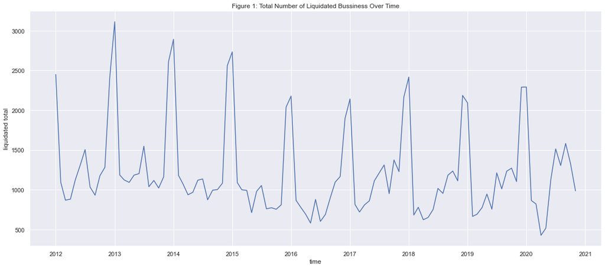

```python
sns.set(rc={'figure.figsize':(19,8)})
ax = sns.lineplot(data = data.liquidated_total)
ax.set(xlabel='time', ylabel='liquidated total', title="Figure 1: Total Number of Liquidated Bussiness Over Time")
plt.show()
```

From the lineplot above, the variance over time for Total Number of Liquidated Bussiness Over Time is seem to be changing Therefore, I will use the log of data.

### Convert Liquidated Bussiness Over Time to the log scale

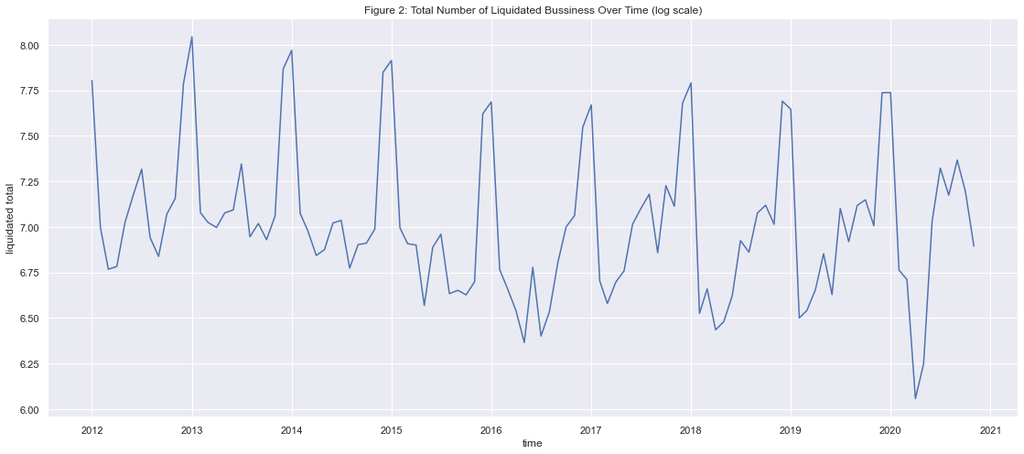

```python
log_data = data.copy()
log_data.liquidated_total = np.log(data.liquidated_total)

ax = sns.lineplot(data = np.log(data.liquidated_total))
ax.set(xlabel='time', ylabel='liquidated total', title="Figure 2: Total Number of Liquidated Bussiness Over Time (log scale)")
plt.show()
```

From the lineplot above, we clearly see that there is strong seasonality in our data and we observe decreasing trend over time. Therefore, I will include both seasonality and trend components to my model. Also, we see a fall in COVID-19 quarantina period, so I will add is_covid columns which is 1 for march and april of 2020 and 0 for other dates.

## 2.3. Build the base model

I will build the base model with trend, seasonality and covid period:

```python
### Add Trend
log_data["trend"] = list(range(1, len(data)+1))

### Add Seasonality
log_data["month"] = log_data.index.month
log_data.month = pd.Categorical(log_data.month)

### Add Covid period
log_data["is_covid"] = 0
log_data.loc[[dt.date(2020,3,1), dt.date(2020,4,1)], "is_covid"] = 1

### Add Constant to log_data:
log_data["const"] = 1
```

```python
lm = LinearRegression()
y = log_data.liquidated_total

X = log_data[["const", "trend", "is_covid"]]
X = pd.concat((X, pd.get_dummies(log_data['month'], drop_first=True)), axis=1)

base_model = OLS(y,X).fit()
base_model.summary()
```

OLS Regression Results

| Dep. Variable: | liquidated_total | R-squared: | 0.776 |
| --- | --- | --- | --- |
| Model: | OLS | Adj. R-squared: | 0.745 |
| Method: | Least Squares | F-statistic: | 24.83 |
| Date: | Sun, 10 Jan 2021 | Prob (F-statistic): | 1.09e-24 |
| Time: | 20:38:44 | Log-Likelihood: | 25.721 |
| No. Observations: | 107 | AIC: | -23.44 |
| Df Residuals: | 93 | BIC: | 13.98 |
| Df Model: | 13 |  |  |
| Covariance Type: | nonrobust |  |  |

|  | coef | std err | t | P>\|t\| | [0.025 | 0.975] |
| --- | --- | --- | --- | --- | --- | --- |
| const | 7.8897 | 0.075 | 104.772 | 0.000 | 7.740 | 8.039 |
| trend | -0.0017 | 0.001 | -2.576 | 0.012 | -0.003 | -0.000 |
| is_covid | -0.2722 | 0.157 | -1.732 | 0.087 | -0.584 | 0.040 |
| 2 | -0.9826 | 0.096 | -10.213 | 0.000 | -1.174 | -0.792 |
| 3 | -1.0144 | 0.098 | -10.379 | 0.000 | -1.208 | -0.820 |
| 4 | -1.1154 | 0.098 | -11.415 | 0.000 | -1.309 | -0.921 |
| 5 | -1.1057 | 0.096 | -11.488 | 0.000 | -1.297 | -0.915 |
| 6 | -0.8812 | 0.096 | -9.154 | 0.000 | -1.072 | -0.690 |
| 7 | -0.7404 | 0.096 | -7.690 | 0.000 | -0.932 | -0.549 |
| 8 | -0.9102 | 0.096 | -9.450 | 0.000 | -1.101 | -0.719 |
| 9 | -0.8338 | 0.096 | -8.653 | 0.000 | -1.025 | -0.642 |
| 10 | -0.7666 | 0.096 | -7.953 | 0.000 | -0.958 | -0.575 |
| 11 | -0.7908 | 0.096 | -8.200 | 0.000 | -0.982 | -0.599 |
| 12 | -0.0763 | 0.099 | -0.769 | 0.444 | -0.273 | 0.121 |

| Omnibus: | 3.460 | Durbin-Watson: | 0.848 |
| --- | --- | --- | --- |
| Prob(Omnibus): | 0.177 | Jarque-Bera (JB): | 2.818 |
| Skew: | -0.345 | Prob(JB): | 0.244 |
| Kurtosis: | 3.394 | Cond. No. | 773. |

Warnings:  
[1] Standard Errors assume that the covariance matrix of the errors is correctly specified.

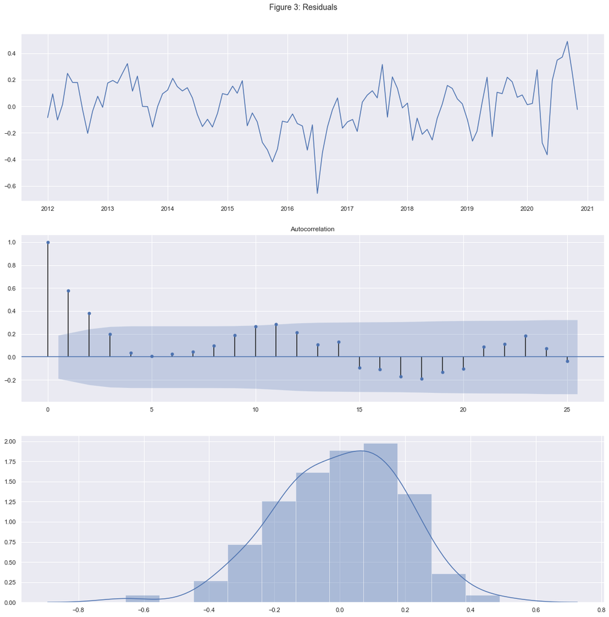

```python
#Set the figure size:
sns.set(rc={'figure.figsize':(19,19)})

#Divide the figure:
fig, axs = plt.subplots(3,1)
fig.suptitle('Figure 3: Residuals', y = 0.92)

#Plot each variable with frgn_deposit_share
sns.lineplot(data = base_model.resid, ax = axs[0])
sm.graphics.tsa.plot_acf(base_model.resid, lags=25, ax = axs[1])
sns.distplot(base_model.resid, ax = axs[2])
```

The observations from the residuals are:

```
1. There is a fall in 2016 July which is probably because of 15 July coup attack. Therefore, I will include is_coup_attack as another feature.
2. Mean for residulas is seem to be 0 and variance looks like constant.
3. For the first lag of the residuals, there is a significant autocorrelation which hopefully will reduce after we add other variables.
4. Distribution of the residuals is seem to be normal.
```

```python
### Add is_coup_attack
log_data["is_coup_attack"] = 0
log_data.loc[[dt.date(2016,7,1)], "is_coup_attack"] = 1

X = log_data[["const", "trend", "is_covid", "is_coup_attack"]]
X = pd.concat((X, pd.get_dummies(log_data['month'], drop_first=True)), axis=1)

coup_added_model = OLS(y,X).fit()
coup_added_model.summary()
```

OLS Regression Results

| Dep. Variable: | liquidated_total | R-squared: | 0.804 |
| --- | --- | --- | --- |
| Model: | OLS | Adj. R-squared: | 0.774 |
| Method: | Least Squares | F-statistic: | 27.00 |
| Date: | Sun, 10 Jan 2021 | Prob (F-statistic): | 1.48e-26 |
| Time: | 20:38:45 | Log-Likelihood: | 32.856 |
| No. Observations: | 107 | AIC: | -35.71 |
| Df Residuals: | 92 | BIC: | 4.380 |
| Df Model: | 14 |  |  |
| Covariance Type: | nonrobust |  |  |

|  | coef | std err | t | P>\|t\| | [0.025 | 0.975] |
| --- | --- | --- | --- | --- | --- | --- |
| const | 7.8897 | 0.071 | 111.393 | 0.000 | 7.749 | 8.030 |
| trend | -0.0017 | 0.001 | -2.739 | 0.007 | -0.003 | -0.000 |
| is_covid | -0.2722 | 0.148 | -1.842 | 0.069 | -0.566 | 0.021 |
| is_coup_attack | -0.7376 | 0.204 | -3.623 | 0.000 | -1.142 | -0.333 |
| 2 | -0.9826 | 0.090 | -10.858 | 0.000 | -1.162 | -0.803 |
| 3 | -1.0144 | 0.092 | -11.035 | 0.000 | -1.197 | -0.832 |
| 4 | -1.1154 | 0.092 | -12.136 | 0.000 | -1.298 | -0.933 |
| 5 | -1.1057 | 0.091 | -12.214 | 0.000 | -1.285 | -0.926 |
| 6 | -0.8812 | 0.091 | -9.732 | 0.000 | -1.061 | -0.701 |
| 7 | -0.6585 | 0.093 | -7.054 | 0.000 | -0.844 | -0.473 |
| 8 | -0.9102 | 0.091 | -10.047 | 0.000 | -1.090 | -0.730 |
| 9 | -0.8338 | 0.091 | -9.200 | 0.000 | -1.014 | -0.654 |
| 10 | -0.7666 | 0.091 | -8.455 | 0.000 | -0.947 | -0.587 |
| 11 | -0.7908 | 0.091 | -8.718 | 0.000 | -0.971 | -0.611 |
| 12 | -0.0763 | 0.093 | -0.818 | 0.416 | -0.262 | 0.109 |

| Omnibus: | 0.577 | Durbin-Watson: | 0.896 |
| --- | --- | --- | --- |
| Prob(Omnibus): | 0.749 | Jarque-Bera (JB): | 0.692 |
| Skew: | -0.040 | Prob(JB): | 0.708 |
| Kurtosis: | 2.614 | Cond. No. | 774. |

Warnings:  
[1] Standard Errors assume that the covariance matrix of the errors is correctly specified.

Now we have a good model with R square = 0.804 and p value = 1.48e-26. In order to improve the model further, I will include some other exogenous variables.

## 2.4. Add possibly related regressors

Now I will try to improve my model by including some regressors to my model. The data I will add is

```
1. USD/TRY excahnge rate,
2. commercial credit interest rate,
3. real sector confidence index,
4. general bussiness situation and
5. present general economic situation,
6. expected general economic situation.
```

I have imported the data in the first part of the homework, you can see the head of my data below.

```python
data.head()
```

| date | usd_try | commercial_credit_int_rate | reel_sector_confidence_index | general_business_situation | general_economic_situation_present | general_economic_situation_expectation | liquidated_total |
| --- | --- | --- | --- | --- | --- | --- | --- |
| 2012-01-01 | 1.847814 | 15.2975 | 102.0 | 96.9 | 98.085568 | 102.247197 | 2449.0 |
| 2012-02-01 | 1.759533 | 14.8650 | 108.7 | 106.0 | 99.959481 | 103.485620 | 1094.0 |
| 2012-03-01 | 1.787882 | 14.1840 | 112.6 | 106.8 | 100.556749 | 102.921379 | 869.0 |
| 2012-04-01 | 1.788420 | 14.1825 | 115.4 | 107.7 | 94.290142 | 94.763702 | 882.0 |
| 2012-05-01 | 1.805627 | 14.0475 | 114.3 | 105.5 | 99.401858 | 102.165174 | 1123.0 |

In order to decide the regressors, I will firstly check the pairplots and correlations.

### Pair Plot

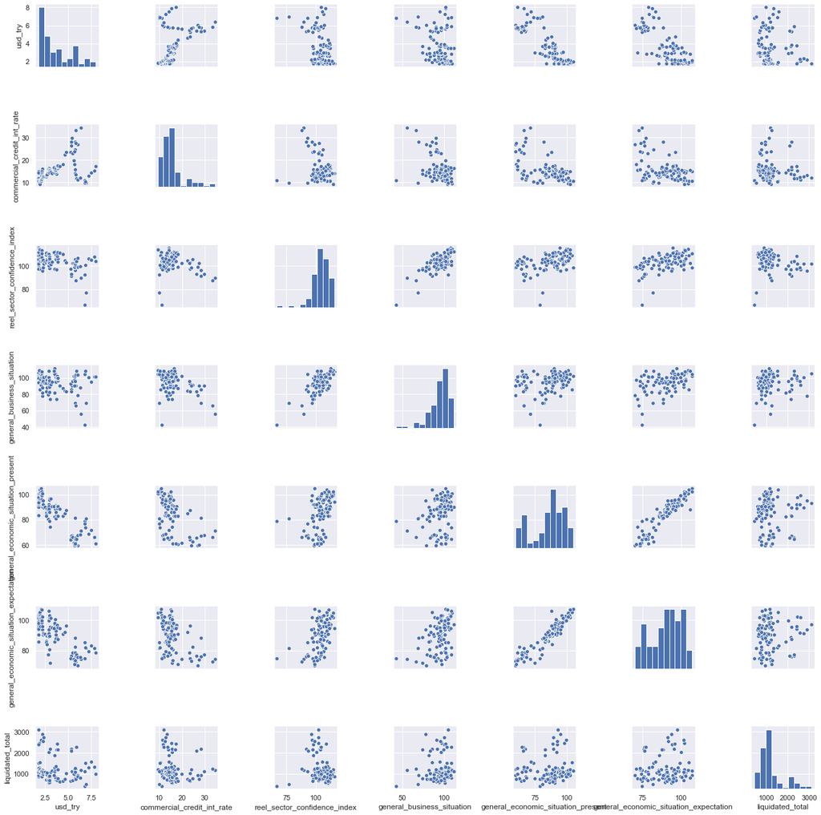

```python
sns.pairplot(data)
```

By visual inspection we don't observe any significant outlier problem for our data. Therefore, I will keep all of my data points.

### Correlation heat map:

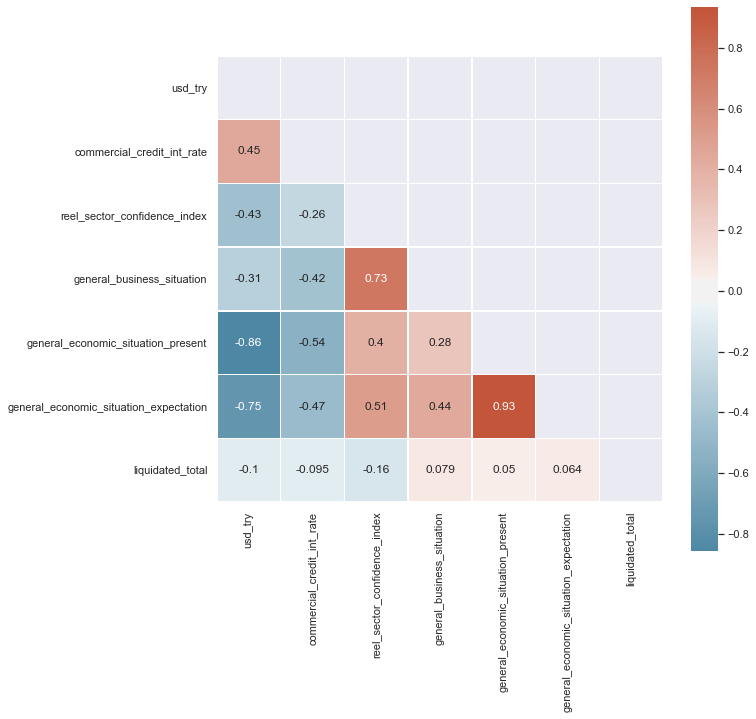

```python
# Compute the correlation matrix
corr = data.corr()
# Draw the heatmap with the mask and correct aspect ratio

mask = np.triu(np.ones_like(corr, dtype=bool)) # Mask for the upper triangle
f, ax = plt.subplots(figsize=(10, 10))
sns.heatmap(corr, mask=mask, cmap=sns.diverging_palette(230, 20, as_cmap=True), annot=True, center=0, square=True, linewidths=.5)
```

From the pair plots and the heat map we see that correlations among 'general_economic_situation_present' and 'general_economic_situation_expectation' and USD/TRY are very high which will cause multicollinearity in the model. Since there is a high correlation between them, one of the three features can explain the others. Therefore, I will drop "general_economic_situation_expectation" and "general_economic_situation_present" which are probably shaped by movements of USD/TRY.

I will also drop "reel sector confidence index" which is corralated with "general business situation".

```python
data = data.drop(["general_economic_situation_present", "general_economic_situation_expectation", "reel_sector_confidence_index"],1)
log_data = log_data.drop(["general_economic_situation_present", "general_economic_situation_expectation", "reel_sector_confidence_index"],1)
```

### Autocorrelation:

```python
data.columns
```

```
Index(['usd_try', 'commercial_credit_int_rate', 'general_business_situation',
       'liquidated_total'],
      dtype='object')
```

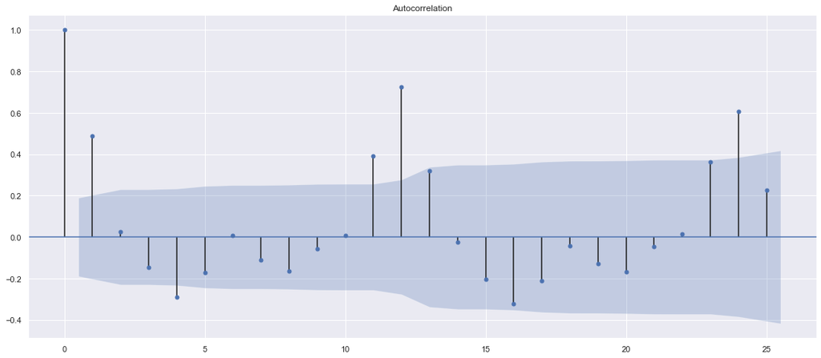

```python
sns.set(rc={'figure.figsize':(19,8)})
ax = sm.graphics.tsa.plot_acf(log_data.liquidated_total, lags=25)

plt.show()
```

We see that there is high correlation with first lag and 12th lag. therefore, I will include the first lag to my model and the dummy variables for seasonality will handle the 12'th lag.

```python
log_data["liquidated_total_L1"] = log_data.liquidated_total.shift(1)
log_data=log_data.dropna()
```

## 2.5. Final Model

```python
X = log_data[['const',
               'usd_try',
               'commercial_credit_int_rate',
               'general_business_situation',
               'trend',
               'is_covid',
               'is_coup_attack',
               'liquidated_total_L1']]

X = pd.concat((X, pd.get_dummies(log_data['month'], drop_first=True)), axis=1)
y= log_data["liquidated_total"]

exo_added_model = OLS(y,X).fit()
exo_added_model.summary()
```

OLS Regression Results

| Dep. Variable: | liquidated_total | R-squared: | 0.890 |
| --- | --- | --- | --- |
| Model: | OLS | Adj. R-squared: | 0.867 |
| Method: | Least Squares | F-statistic: | 39.15 |
| Date: | Sun, 10 Jan 2021 | Prob (F-statistic): | 5.33e-34 |
| Time: | 20:38:59 | Log-Likelihood: | 64.585 |
| No. Observations: | 106 | AIC: | -91.17 |
| Df Residuals: | 87 | BIC: | -40.56 |
| Df Model: | 18 |  |  |
| Covariance Type: | nonrobust |  |  |

|  | coef | std err | t | P>\|t\| | [0.025 | 0.975] |
| --- | --- | --- | --- | --- | --- | --- |
| const | 3.9384 | 0.609 | 6.464 | 0.000 | 2.727 | 5.149 |
| usd_try | 0.0750 | 0.028 | 2.651 | 0.010 | 0.019 | 0.131 |
| commercial_credit_int_rate | -0.0011 | 0.004 | -0.289 | 0.774 | -0.009 | 0.006 |
| general_business_situation | 0.0034 | 0.002 | 1.990 | 0.050 | 3.44e-06 | 0.007 |
| trend | -0.0044 | 0.002 | -2.747 | 0.007 | -0.008 | -0.001 |
| is_covid | -0.2554 | 0.132 | -1.929 | 0.057 | -0.518 | 0.008 |
| is_coup_attack | -0.6064 | 0.155 | -3.905 | 0.000 | -0.915 | -0.298 |
| liquidated_total_L1 | 0.4602 | 0.082 | 5.590 | 0.000 | 0.297 | 0.624 |
| 2 | -1.0450 | 0.071 | -14.716 | 0.000 | -1.186 | -0.904 |
| 3 | -0.6242 | 0.107 | -5.817 | 0.000 | -0.838 | -0.411 |
| 4 | -0.6925 | 0.110 | -6.291 | 0.000 | -0.911 | -0.474 |
| 5 | -0.6476 | 0.116 | -5.586 | 0.000 | -0.878 | -0.417 |
| 6 | -0.4426 | 0.114 | -3.885 | 0.000 | -0.669 | -0.216 |
| 7 | -0.3287 | 0.100 | -3.284 | 0.001 | -0.528 | -0.130 |
| 8 | -0.6324 | 0.091 | -6.935 | 0.000 | -0.814 | -0.451 |
| 9 | -0.4720 | 0.100 | -4.712 | 0.000 | -0.671 | -0.273 |
| 10 | -0.4472 | 0.096 | -4.638 | 0.000 | -0.639 | -0.256 |
| 11 | -0.5239 | 0.096 | -5.470 | 0.000 | -0.714 | -0.334 |
| 12 | 0.2381 | 0.094 | 2.541 | 0.013 | 0.052 | 0.424 |

| Omnibus: | 1.271 | Durbin-Watson: | 2.002 |
| --- | --- | --- | --- |
| Prob(Omnibus): | 0.530 | Jarque-Bera (JB): | 1.317 |
| Skew: | -0.193 | Prob(JB): | 0.517 |
| Kurtosis: | 2.613 | Cond. No. | 5.23e+03 |

Warnings:  
[1] Standard Errors assume that the covariance matrix of the errors is correctly specified.  
[2] The condition number is large, 5.23e+03. This might indicate that there are  
strong multicollinearity or other numerical problems.

The regressors that we have added improved our model. Finally, we can check residuals if there is anything that we can add to improve the model further.

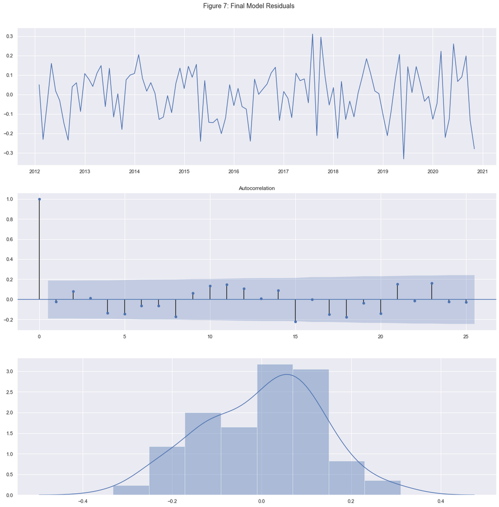

```python
#Set the figure size:
sns.set(rc={'figure.figsize':(19,19)})

#Divide the figure:
fig, axs = plt.subplots(3,1)
fig.suptitle('Figure 7: Final Model Residuals', y = 0.92)

#Plot each variable with frgn_deposit_share
sns.lineplot(data = exo_added_model.resid, ax = axs[0])
sm.graphics.tsa.plot_acf(exo_added_model.resid, lags=25, ax = axs[1])
sns.distplot(exo_added_model.resid, ax = axs[2])
```

The residuals are seem to be satisfying the white noise assumptions. Therefore, we don't need to add anything further to our model. Now I will use my model to predict December 2020.

## 2.6 Predictions of the model

```python
december_2020
```

[output not shown]

```python
#Prepare the data for December 2020

december_2020["const"] = 1
december_2020["trend"] = 108
december_2020["is_covid"] = 0
december_2020["is_coup_attack"] = 0
december_2020["liquidated_total_L1"] = math.log(data.loc[dt.date(2020,11,1), "liquidated_total"])
december_2020[2] = 0
december_2020[3] = 0
december_2020[4] = 0
december_2020[5] = 0
december_2020[6] = 0
december_2020[7] = 0
december_2020[8] = 0
december_2020[9] = 0
december_2020[10] = 0
december_2020[11] = 0
december_2020[12] = 1
december_2020=december_2020.dropna()[X.columns]
```

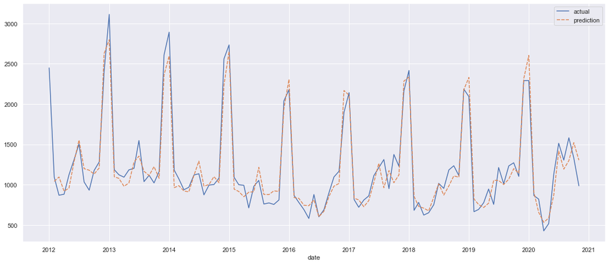

```python
sns.set(rc={'figure.figsize':(19,8)})
preds_and_actual = pd.DataFrame()
preds_and_actual["actual"] = data.liquidated_total
preds_and_actual["prediction"] =  np.exp(exo_added_model.predict(X))

sns.lineplot(data =preds_and_actual)
```

```python
np.exp(exo_added_model.predict(december_2020.values))[0]
```

```
1684.9114728298575
```

This is the prediction of our model for December 2020.

# 3. Conclusion

In this homework I have established a model that can predict next month's liquadated firm count. In the model, I have handled the monthly seasonality by adding dummy variables for each month. There was a falling trend in the data and it is handled by adding a trend feature which is a sequence from 1 to 107. The target variable, liquadated firm count, was seem to be affected by COVID-19 period and 15 July coup attack. In order to handle the errors in those periods, the variables is_covid and is_coup_attack added to model which are 1 during the relevant periods and 0 for other times. Those 2 variables are important to model extra-ordinary situations on liquadated firm count and can be used in other for example pandemic periods. Only by looking those variables, we got a good model but in order to improve our model further, I have checked

```
1. USD/TRY excahnge rate,
2. commercial credit interest rate,
3. real sector confidence index,
4. general bussiness situation and
5. present general economic situation,
6. expected general economic situation
```